# Stroop Effect

Ratik Dugar

```
## [1] "C:/Users/rdugar/Desktop/udacity/stats"
```

In a Stroop task, participants are presented with a list of words, with each word displayed in a color of ink. The participant’s task is to say out loud the color of the ink in which the word is printed. The task has two conditions: a congruent words condition, and an incongruent words condition. In the congruent words condition, the words being displayed are color words whose names match the colors in which they are printed. In the incongruent words condition, the words displayed are color words whose names do not match the colors in which they are printed. In each case, we measure the time it takes to name the ink colors in equally-sized lists. Each participant will go through and record a time from each condition.

# Investigation

### 1. What is our independent variable? What is our dependent variable?

**Independent Variable:** The word/color congruency status. This is the variable that forms the basis of our 2 groups- Congruent and Incongruent.

**Dependent Variable:** The time taken by a participant to go through and name all the ink colors in 2 equally sized lists.

### 2. What is an appropriate set of hypotheses for this task? What kind of statistical test do you expect to perform? Justify your choices.

From looking at the data we can see that time taken by partcipants to name incongruent words/colors is more than that of the congruent list. Keeping that in mind, my **Null Hypothesis**($H_{0}$) would be that the time taken to name the Incongruent list of words would decrease or remain unchanged when compared to the time taken to name the congruent list of words. My **Alternate Hypothesis**($H_{a}$) would be that the time taken to name the Incongruent list of words would be more than of the congruent list of words.

$H_{0}$: $\mu_{i}$ $\le$ $\mu_{c}$ $H_{a}$: $\mu_{i}$ $\gt$ $\mu_{c}$

where, $\mu_{i}$ population mean of incongruent time values while $\mu_{c}$ is the population mean of congruent time values)

**Statistical Test:**

In order to test the hypotheses I declared above, I would use the following:

**One Tailed Dependent Samples t-test** at a

**95% Confidence level**($\alpha$ = 0.05)

I am using a t-test because we dont know the population standard deviation and our sample size is less than 30 and therefore, we cannot use the z-test. It is a paired t test because each participant is tested twice - once for the congruent list of color names and then for an equally sized list of incongruent color names. This t-test is going to be one tailed because of our one directional alternative assumption that the time taken to name the incongruent set is more than the time taken to name the congruent set.

### 3. Report some descriptive statistics regarding this dataset. Include at least one measure of central tendency and at least one measure of variability.

```r
stroop$Diff<-stroop$Incongruent-stroop$Congruent
summary(stroop)
```

```
##    Congruent      Incongruent         Diff
##  Min.   : 8.63   Min.   :15.69   Min.   : 1.950
##  1st Qu.:11.90   1st Qu.:18.72   1st Qu.: 3.646
##  Median :14.36   Median :21.02   Median : 7.667
##  Mean   :14.05   Mean   :22.02   Mean   : 7.965
##  3rd Qu.:16.20   3rd Qu.:24.05   3rd Qu.:10.258
##  Max.   :22.33   Max.   :35.26   Max.   :21.919
```

```r
sd_congruent<-sd(stroop$Congruent)
sd_incongruent<-sd(stroop$Incongruent)
sd_diff<-sd(stroop$Diff)
sd_congruent
```

```
## [1] 3.559358
```

```r
sd_incongruent
```

```
## [1] 4.797057
```

```r
sd_diff
```

```
## [1] 4.864827
```

From the summary statistics we generate above,

**Mean:**

for Congruent($\bar{x}_{1}$)=14.05, for Incongruent($\bar{x}_{2}$)=22.02

**Median:** for Congruent=14.36, for Incongruent :21.02

The median is a better measure of central tendancy in this case because from the frequency distribution, it looks the like the data does not follow a normal distribution and might be a little skewed.

The **sample standard deviation(s)** = $\sum{(x - \bar{x})^2}/n-1$ for Congruent=3.56, for Incongruent=4.80

**Interquartile Range(Q3-Q1):** for Congruent=4.3, for Incongruent=5.33

### 4. Provide one or two visualizations that show the distribution of the sample data. Write one or two sentences noting what you observe about the plot or plots.

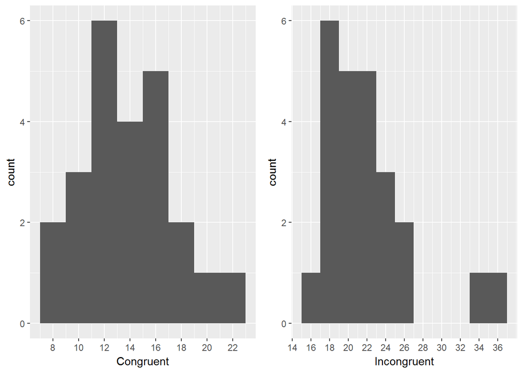

From the above plots we can see the frequency distribution of both the groups. The mean and median time for the congruent set both look like they would be around 14 while for the Incongruent set it looks like it should be around 21-22. This is confirmed above through the summary statistics. The congruent histogram distribution looks more normal and than the incongruent but both seem to be slightly skewed to the right. The median for the incongruent set is slightly less than the mean, again showing the effect of positive skewness. Interestingly,there are no time values between 27 and 33 for the Incongruent set.

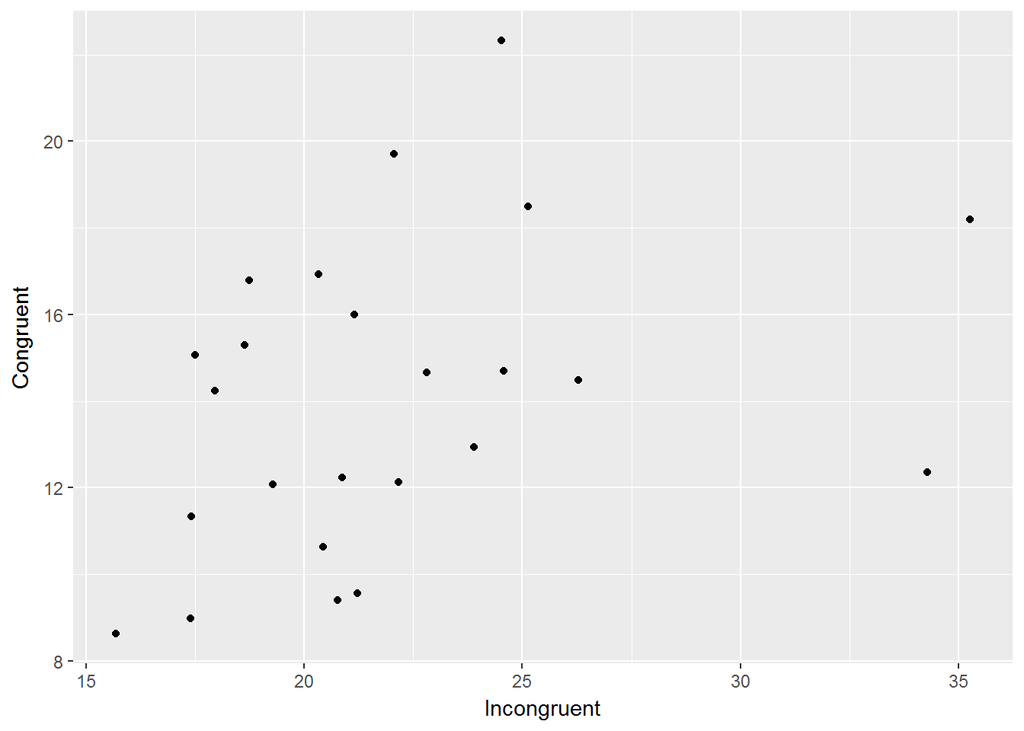

```r
with(stroop,cor.test(Congruent,Incongruent,prob=0.99,method='pearson'))
```

```
##
##  Pearson's product-moment correlation
##
## data:  Congruent and Incongruent
## t = 1.7629, df = 22, p-value = 0.09181
## alternative hypothesis: true correlation is not equal to 0
## 95 percent confidence interval:
##  -0.06010786  0.66135488
## sample estimates:
##       cor
## 0.3518195
```

The scatterplot between the congruent and incongruent timings show that there is a positive correlation although it might not be very strong based on the fairly dispursed plotting. I calculated the coefficient of correlation between timings of the 2 groups and indeed, it turned out to be 0.35. I can also see that there are 2 outliers with very high incongruent timings and these are the reason why we saw a gap between the values of 27 and 33 earlier on.

### 5. Now, perform the statistical test and report your results. What is your confidence level and your critical statistic value? Do you reject the null hypothesis or fail to reject it? Come to a conclusion in terms of the experiment task. Did the results match up with your expectations?

In order to perform the statistical test, we first need to calculate the difference between the congruent and incongruent timings for each participant which we did above. From the summary above, we know that the **mean difference** ($\bar{x}_{2}$-$\bar{x}_{1}$)=7.965. We also calculated the **standard deviation**($s_{diff}$) for the difference above and it turned out to be 4.86.

Using the one-tailed t-test,

$\alpha$=0.05

**sample size(n)**=24

**degrees of freedom(df)**=n-1=23

Using the t-table I found that the $t_{critical}$=1.714

**Standard Error of the difference:**

($SE_{D}$)=($s_{diff}$)/($\sqrt{n}$)=4.86/$\sqrt{24}$=0.993

$t_{statistic}$=Mean difference/$SE_{D}$=7.965/0.993=8.02

The t-statistic value is in the critical region and greater than the t-critical value so we can say that our result is statistically significant at an $\alpha$ level of 0.05 with degrees of freedom=23

Using the t-distribution table I conclude that the p-value<0.0001 therefore, the result is statistically significant as the p-value<$\alpha$=0.05

Thus, we *reject the null hypothesis*($H_{0}$) and conclude that the incongruent list of words/colors does indeed have a greater time response than the congruent list of words/colors.

This result in line with our expectation.

**The 95% Confidence Interval:**

$t_{critical}$=2.069 for two-tailed t-distribution at $\alpha$=0.05

CI: Mean difference $\pm$ $t_{critical}$$*$$SE_{D}$=7.965 $\pm$ 2.069$*$.993= (5.91,10.02)

### 6.Optional: What do you think is responsible for the effects observed? Can you think of an alternative or similar task that would result in a similar effect? Some research about the problem will be helpful for thinking about these two questions!

I think that the delay in reaction is caused by parallel distributed processing. The theory believes that the brain analyzes information and in doing so, it creates different and specific pathways for different tasks. A task like reading has a stronger pathway than recognizing colors and when both of these tasks are activated at the same time, the stronger pathway acts as an interference when we are expecting a response from the weaker pathway. This is what causes the delayed reaction. I don’t think humans are slower at processing color and this could be quantified by timing a list of just colors that turn up on the screen. I suspect our reaction in that case would be about the same when compared to naming words that show up. An experiment that brings out a similar Stroop effect is recognizing geometric shapes with their corresponding names versus geometric shapes with mismatched names.

# References

https://en.wikipedia.org/wiki/Stroop_effect

http://www.statpower.net/Content/310/R%20Stuff/SampleMarkdown.html

http://pages.stat.wisc.edu/~jgillett/327-1/RMarkdown.pdf